# PartB

Ulita Gilbert

05/03/2021

# 1 Data Dictionary

For the purposes of this EDA, the following variables and definitions are important.

The population in this dataset is the incoming cohort of students in Fall of 2019 and 2020. These students are first time degree or certificate seekers and have no prior tertiary education. They may have earned AP credits in highschool.

**Fall2019** refers to the incoming freshman cohort in Fall2019. This is term year 2020.  
**Fall2020** refers to the incoming freshman cohort in Fall2020. This is term year 2021.

**Variables of Interest:**  
**hours_earned:** refers to credit hours the student has earned in their first Fall semester ( this can include credits earned in Summer school second session- Summer 1 and AP credits earned in highschool).  
**hours_attempted:** refers to credit and non credit hours the student has attempted in their first Fall semester ( this may include credits attempted in Summerschool second session - Summer 1).

**full_part:** is the student full-time (FT) or part-time (PT). Part time students are registered in less than 12 credit hours. Full-time students take at least 12 credits.

**major:** degree programme student is registered for or certificate&LR ( letter of recommendation.) All certificates and letters of recommendations have been grouped together.

**hours_earned_rate:** Ratio of hours_earned/hours_attempted

# 2 Data Wrangling

## 2.1 Import Data

```r
#import data for Fall 2016 to Fall 2020
# set directory
setwd('/Users/ulita/Documents/CAPSTONE205/Capstone/Capstone_Data/Raw_Data')

initial_df_2019<-read_xlsx("FTEIC F19.xlsx")
initial_df_2020<-read_xlsx("FTEIC F20.xlsx")
```

## 2.2 Create Dataframe

```r
 #create dataframe to compare credits in Fall 2019 and Fall 2020 :    df_credits
df_initial<- bind_rows(initial_df_2019,initial_df_2020)

head(df_initial)
```

```
## # A tibble: 6 x 50
##   `U-Number` Sex   IPEDS_RACE_DESC `Age at Start` HIGH_SCHOOL FULL_PART CITY
##        <dbl> <chr> <chr>           <chr>          <chr>       <chr>     <chr>
## 1   20190001 F     Hispanic        18 - 20        Out of Sta… PT        Gait…
## 2   20190002 M     Hispanic        18 - 20        Walter Joh… FT        Rock…
## 3   20190003 F     Multi-Race      18 - 20        Wheaton Hi… PT        Gait…
## 4   20190004 M     Asian           18 - 20        Thomas Spr… PT        Gait…
## 5   20190005 M     Hispanic        18 - 20        FOREIGN / … FT        Chev…
## 6   20190006 F     Hispanic        18 - 20        Springbroo… FT        Silv…
## # … with 43 more variables: STAT_CODE <chr>, ZIP <dbl>, PELL_GRANT <chr>,
## #   CAMP_CODE <chr>, Major <chr>, HOURS_ATTEMPTED <chr>, HOURS_EARNED <chr>,
## #   MC_GPA <dbl>, PASS_ENGL <chr>, PASS_MATH <chr>, term_year <chr>,
## #   TERM_YEAR1_10 <chr>, TERM_YEAR1_20 <chr>, TERM_YEAR1_24 <chr>,
## #   TERM_YEAR1_25 <chr>, TERM_YEAR1_30 <chr>, TERM_YEAR1_40 <chr>,
## #   TERM_YEAR2_10 <chr>, TERM_YEAR2_20 <chr>, TERM_YEAR2_24 <chr>,
## #   TERM_YEAR2_25 <chr>, TERM_YEAR2_30 <chr>, TERM_YEAR2_40 <chr>,
## #   TERM_YEAR3_10 <chr>, TERM_YEAR3_20 <chr>, TERM_YEAR3_24 <chr>,
## #   TERM_YEAR3_25 <chr>, TERM_YEAR3_30 <chr>, TERM_YEAR3_40 <chr>,
## #   TERM_YEAR4_10 <chr>, TERM_YEAR4_20 <chr>, TERM_YEAR4_24 <chr>,
## #   TERM_YEAR4_25 <chr>, TERM_YEAR4_30 <chr>, TERM_YEAR4_40 <chr>,
## #   TERM_YEAR5_10 <chr>, TERM_YEAR5_20 <chr>, TERM_YEAR5_24 <chr>,
## #   TERM_YEAR5_25 <chr>, TERM_YEAR5_30 <chr>, first_grad_date <lgl>,
## #   first_degree <lgl>, TERM_YEAR5_40 <chr>
```

## 2.3 Select Columns of Interest & Format Names

```r
#clean names using janitor package
df_initial<-df_initial %>%
             clean_names()

#drop columns not interested in

df_initial<-df_initial %>%
             select(c(1:20))

# rename columns to make it user friendly
df_initial<-df_initial %>%
            rename("age"= "age_at_start", "race"= "ipeds_race_desc", 'summer1'= "term_year1_10", 'fall'='term_year1_20')
```

## 2.4 Overview of Data

```r
# summary statistics of dataframing using function skimr creates a table of summary statistics of all variables in the dataframe
skim(df_initial)
```

Data summary

| Name | df_initial |
| --- | --- |
| Number of rows | 7519 |
| Number of columns | 20 |
| _______________________ |  |
| Column type frequency: |  |
| character | 17 |
| numeric | 3 |
| ________________________ |  |
| Group variables | None |

**Variable type: character**

| skim_variable | n_missing | complete_rate | min | max | empty | n_unique | whitespace |
| --- | --- | --- | --- | --- | --- | --- | --- |
| sex | 0 | 1.00 | 1 | 1 | 0 | 4 | 0 |
| race | 0 | 1.00 | 5 | 22 | 0 | 9 | 0 |
| age | 0 | 1.00 | 4 | 7 | 0 | 5 | 0 |
| high_school | 0 | 1.00 | 7 | 30 | 0 | 172 | 0 |
| full_part | 0 | 1.00 | 2 | 2 | 0 | 2 | 0 |
| city | 21 | 1.00 | 5 | 19 | 0 | 132 | 0 |
| stat_code | 21 | 1.00 | 2 | 2 | 0 | 16 | 0 |
| pell_grant | 0 | 1.00 | 1 | 1 | 0 | 2 | 0 |
| camp_code | 154 | 0.98 | 1 | 1 | 0 | 6 | 0 |
| major | 33 | 1.00 | 1 | 61 | 0 | 35 | 0 |
| hours_attempted | 87 | 0.99 | 2 | 4 | 0 | 55 | 0 |
| hours_earned | 87 | 0.99 | 2 | 4 | 0 | 56 | 0 |
| pass_engl | 0 | 1.00 | 1 | 1 | 0 | 2 | 0 |
| pass_math | 0 | 1.00 | 1 | 1 | 0 | 2 | 0 |
| term_year | 0 | 1.00 | 4 | 4 | 0 | 2 | 0 |
| summer1 | 50 | 0.99 | 1 | 1 | 0 | 1 | 0 |
| fall | 50 | 0.99 | 1 | 1 | 0 | 2 | 0 |

**Variable type: numeric**

| skim_variable | n_missing | complete_rate | mean | sd | p0 | p25 | p50 | p75 | p100 | hist |
| --- | --- | --- | --- | --- | --- | --- | --- | --- | --- | --- |
| u_number | 0 | 1.00 | 20196656.07 | 5028.73 | 20190001 | 20191880.5 | 20193760.0 | 20201708.5 | 20203588 | ▇▃▁▂▇ |
| zip | 21 | 1.00 | 20884.18 | 1518.62 | 1460 | 20853.0 | 20877.0 | 20902.0 | 94025 | ▁▇▁▁▁ |
| mc_gpa | 87 | 0.99 | 2.16 | 1.48 | 0 | 0.5 | 2.5 | 3.5 | 4 | ▆▂▃▅▇ |

## 2.5 Change Datatypes

```r
# Change datatypes
df_initial$hours_attempted<- as.integer(df_initial$hours_attempted)
df_initial$hours_earned<- as.integer(df_initial$hours_earned)
df_initial$mc_gpa<- as.double(df_initial$mc_gpa)
df_initial$u_number<- as.character(df_initial$u_number)
df_initial$zip<- as.character(df_initial$zip)

#drop missing values in hours_attempted, hours_earned and mc_gap

df_initial <- df_initial %>%
              drop_na(hours_attempted,hours_earned)
```

Summarise data again

```r
skim(df_initial)
```

Data summary

| Name | df_initial |
| --- | --- |
| Number of rows | 7432 |
| Number of columns | 20 |
| _______________________ |  |
| Column type frequency: |  |
| character | 17 |
| numeric | 3 |
| ________________________ |  |
| Group variables | None |

**Variable type: character**

| skim_variable | n_missing | complete_rate | min | max | empty | n_unique | whitespace |
| --- | --- | --- | --- | --- | --- | --- | --- |
| u_number | 0 | 1.00 | 8 | 8 | 0 | 7432 | 0 |
| sex | 0 | 1.00 | 1 | 1 | 0 | 4 | 0 |
| race | 0 | 1.00 | 5 | 22 | 0 | 9 | 0 |
| age | 0 | 1.00 | 4 | 7 | 0 | 5 | 0 |
| high_school | 0 | 1.00 | 7 | 30 | 0 | 171 | 0 |
| full_part | 0 | 1.00 | 2 | 2 | 0 | 2 | 0 |
| city | 20 | 1.00 | 5 | 19 | 0 | 131 | 0 |
| stat_code | 20 | 1.00 | 2 | 2 | 0 | 16 | 0 |
| zip | 20 | 1.00 | 4 | 5 | 0 | 166 | 0 |
| pell_grant | 0 | 1.00 | 1 | 1 | 0 | 2 | 0 |
| camp_code | 152 | 0.98 | 1 | 1 | 0 | 6 | 0 |
| major | 33 | 1.00 | 1 | 61 | 0 | 35 | 0 |
| pass_engl | 0 | 1.00 | 1 | 1 | 0 | 2 | 0 |
| pass_math | 0 | 1.00 | 1 | 1 | 0 | 2 | 0 |
| term_year | 0 | 1.00 | 4 | 4 | 0 | 2 | 0 |
| summer1 | 8 | 1.00 | 1 | 1 | 0 | 1 | 0 |
| fall | 8 | 1.00 | 1 | 1 | 0 | 1 | 0 |

**Variable type: numeric**

| skim_variable | n_missing | complete_rate | mean | sd | p0 | p25 | p50 | p75 | p100 | hist |
| --- | --- | --- | --- | --- | --- | --- | --- | --- | --- | --- |
| hours_attempted | 0 | 1 | 12.29 | 6.27 | 0 | 9.0 | 12.0 | 15.0 | 54 | ▆▇▁▁▁ |
| hours_earned | 0 | 1 | 7.72 | 7.40 | 0 | 3.0 | 6.0 | 12.0 | 54 | ▇▃▁▁▁ |
| mc_gpa | 0 | 1 | 2.16 | 1.48 | 0 | 0.5 | 2.5 | 3.5 | 4 | ▆▂▃▅▇ |

After removing the missing values in hours_earned and hours_attempted. There are 8 missing values in Fall. Closer inspection shows that these 8 students have a GPA of 0 even though there are hours attempted and hours earned. I will remove these students.

```r
# remove students whose Fall term is NA

df_initial <- df_initial%>%
              filter(., !is.na(fall))

skim(df_initial)
```

Data summary

| Name | df_initial |
| --- | --- |
| Number of rows | 7424 |
| Number of columns | 20 |
| _______________________ |  |
| Column type frequency: |  |
| character | 17 |
| numeric | 3 |
| ________________________ |  |
| Group variables | None |

**Variable type: character**

| skim_variable | n_missing | complete_rate | min | max | empty | n_unique | whitespace |
| --- | --- | --- | --- | --- | --- | --- | --- |
| u_number | 0 | 1.00 | 8 | 8 | 0 | 7424 | 0 |
| sex | 0 | 1.00 | 1 | 1 | 0 | 4 | 0 |
| race | 0 | 1.00 | 5 | 22 | 0 | 9 | 0 |
| age | 0 | 1.00 | 4 | 7 | 0 | 5 | 0 |
| high_school | 0 | 1.00 | 7 | 30 | 0 | 170 | 0 |
| full_part | 0 | 1.00 | 2 | 2 | 0 | 2 | 0 |
| city | 20 | 1.00 | 5 | 19 | 0 | 131 | 0 |
| stat_code | 20 | 1.00 | 2 | 2 | 0 | 16 | 0 |
| zip | 20 | 1.00 | 4 | 5 | 0 | 166 | 0 |
| pell_grant | 0 | 1.00 | 1 | 1 | 0 | 2 | 0 |
| camp_code | 152 | 0.98 | 1 | 1 | 0 | 6 | 0 |
| major | 33 | 1.00 | 1 | 61 | 0 | 35 | 0 |
| pass_engl | 0 | 1.00 | 1 | 1 | 0 | 2 | 0 |
| pass_math | 0 | 1.00 | 1 | 1 | 0 | 2 | 0 |
| term_year | 0 | 1.00 | 4 | 4 | 0 | 2 | 0 |
| summer1 | 0 | 1.00 | 1 | 1 | 0 | 1 | 0 |
| fall | 0 | 1.00 | 1 | 1 | 0 | 1 | 0 |

**Variable type: numeric**

| skim_variable | n_missing | complete_rate | mean | sd | p0 | p25 | p50 | p75 | p100 | hist |
| --- | --- | --- | --- | --- | --- | --- | --- | --- | --- | --- |
| hours_attempted | 0 | 1 | 12.29 | 6.27 | 0 | 9.0 | 12.0 | 15.0 | 54 | ▆▇▁▁▁ |
| hours_earned | 0 | 1 | 7.72 | 7.40 | 0 | 3.0 | 6.0 | 12.0 | 54 | ▇▃▁▁▁ |
| mc_gpa | 0 | 1 | 2.16 | 1.48 | 0 | 0.5 | 2.5 | 3.5 | 4 | ▆▂▃▅▇ |

## 2.6 Missing Values and data Anomalies

```r
df_initial%>% group_by(term_year,full_part)%>%
                      count(hours_attempted==0)
```

```
## # A tibble: 7 x 4
## # Groups:   term_year, full_part [4]
##   term_year full_part `hours_attempted == 0`     n
##   <chr>     <chr>     <lgl>                  <int>
## 1 2020      FT        FALSE                   2251
## 2 2020      FT        TRUE                       3
## 3 2020      PT        FALSE                   1606
## 4 2020      PT        TRUE                      27
## 5 2021      FT        FALSE                   2147
## 6 2021      PT        FALSE                   1373
## 7 2021      PT        TRUE                      17
```

Term year 2020: There are 3 full time and 27 part time students who attempted zero hours. Term year 2021: There are 17 part time students who attempted zero hours. These 47 observations will be dropped.

```r
# remove students who attempted 0 hours

df_initial <- df_initial%>%
              filter(., hours_attempted != 0)

skim(df_initial)
```

Data summary

| Name | df_initial |
| --- | --- |
| Number of rows | 7377 |
| Number of columns | 20 |
| _______________________ |  |
| Column type frequency: |  |
| character | 17 |
| numeric | 3 |
| ________________________ |  |
| Group variables | None |

**Variable type: character**

| skim_variable | n_missing | complete_rate | min | max | empty | n_unique | whitespace |
| --- | --- | --- | --- | --- | --- | --- | --- |
| u_number | 0 | 1.00 | 8 | 8 | 0 | 7377 | 0 |
| sex | 0 | 1.00 | 1 | 1 | 0 | 4 | 0 |
| race | 0 | 1.00 | 5 | 22 | 0 | 9 | 0 |
| age | 0 | 1.00 | 4 | 7 | 0 | 5 | 0 |
| high_school | 0 | 1.00 | 7 | 30 | 0 | 168 | 0 |
| full_part | 0 | 1.00 | 2 | 2 | 0 | 2 | 0 |
| city | 19 | 1.00 | 5 | 19 | 0 | 130 | 0 |
| stat_code | 19 | 1.00 | 2 | 2 | 0 | 16 | 0 |
| zip | 19 | 1.00 | 4 | 5 | 0 | 164 | 0 |
| pell_grant | 0 | 1.00 | 1 | 1 | 0 | 2 | 0 |
| camp_code | 152 | 0.98 | 1 | 1 | 0 | 6 | 0 |
| major | 33 | 1.00 | 1 | 61 | 0 | 35 | 0 |
| pass_engl | 0 | 1.00 | 1 | 1 | 0 | 2 | 0 |
| pass_math | 0 | 1.00 | 1 | 1 | 0 | 2 | 0 |
| term_year | 0 | 1.00 | 4 | 4 | 0 | 2 | 0 |
| summer1 | 0 | 1.00 | 1 | 1 | 0 | 1 | 0 |
| fall | 0 | 1.00 | 1 | 1 | 0 | 1 | 0 |

**Variable type: numeric**

| skim_variable | n_missing | complete_rate | mean | sd | p0 | p25 | p50 | p75 | p100 | hist |
| --- | --- | --- | --- | --- | --- | --- | --- | --- | --- | --- |
| hours_attempted | 0 | 1 | 12.36 | 6.21 | 1 | 9.00 | 12.0 | 15.0 | 54 | ▆▇▁▁▁ |
| hours_earned | 0 | 1 | 7.77 | 7.39 | 0 | 3.00 | 6.0 | 12.0 | 54 | ▇▃▁▁▁ |
| mc_gpa | 0 | 1 | 2.18 | 1.48 | 0 | 0.67 | 2.5 | 3.5 | 4 | ▆▂▃▅▇ |

Check missing values in variable major

```r
#check majors list for undeclared and missing values.

df_initial%>% count(major)
```

```
## # A tibble: 36 x 2
##    major                        n
##    <chr>                    <int>
##  1 0                           16
##  2 American Sign Language      12
##  3 Applied Geography           10
##  4 Architectural Technology    74
##  5 Art                        108
##  6 Broadcast Media             29
##  7 Building Trade              88
##  8 Business                   879
##  9 Certificate & LR           221
## 10 Communication               68
## # … with 26 more rows
```

```r
dim(df_initial)
```

```
## [1] 7377   20
```

# 3 Initial Data Analysis

```r
#remove certificates, NA refers to degree majors which have not been named to protect student privacy.
df_Degrees<-subset(df_initial, major!="Certificate & LR" || major =='NA')
df_Degrees%>%count(major)
```

```
## # A tibble: 36 x 2
##    major                        n
##    <chr>                    <int>
##  1 0                           16
##  2 American Sign Language      12
##  3 Applied Geography           10
##  4 Architectural Technology    74
##  5 Art                        108
##  6 Broadcast Media             29
##  7 Building Trade              88
##  8 Business                   879
##  9 Certificate & LR           221
## 10 Communication               68
## # … with 26 more rows
```

##Demographics of Degree Seeking Students

### 3.0.1 Full time versus Part-time Degree Students

```r
#count number of full time versus part-time degree students.

df_Degrees%>% group_by(term_year)%>%
                     count(full_part)
```

```
## # A tibble: 4 x 3
## # Groups:   term_year [2]
##   term_year full_part     n
##   <chr>     <chr>     <int>
## 1 2020      FT         2251
## 2 2020      PT         1606
## 3 2021      FT         2147
## 4 2021      PT         1373
```

## 3.1 Registration in Summer School 1

Hours attempted in Summer 1 are reported with hours_attempted in Fall. Credits earned in Summer 1 are usually reported with hours earned in Fall.

```r
#count number of full time versus part-time degree students.

df_Degrees%>% group_by(term_year,full_part)%>%
                     count(summer1=='Y')
```

```
## # A tibble: 4 x 4
## # Groups:   term_year, full_part [4]
##   term_year full_part `summer1 == "Y"`     n
##   <chr>     <chr>     <lgl>            <int>
## 1 2020      FT        FALSE             2251
## 2 2020      PT        FALSE             1606
## 3 2021      FT        FALSE             2147
## 4 2021      PT        FALSE             1373
```

There are 0 students who have attended Summer1. Hence values reported for hours_earned are only for credits earned in fall and AP credits. Hours attempted in Fall are only for non credit developmental courses and credit courses taken in Fall.

## 3.2 Hours Attempted by Degree Seeking Students

```r
# AP credits can be given for courses taken at highschool.
#Check number of students with hours_earned greater than hours_attempted

df_Degrees %>% count(hours_attempted<hours_earned)
```

```
## # A tibble: 2 x 2
##   `hours_attempted < hours_earned`     n
##   <lgl>                            <int>
## 1 FALSE                             7372
## 2 TRUE                                 5
```

There are 5 students with attempted hours smaller than hours earned. This may be due to AP credits ( credits earned in high school) and will be addressed later.

Histogram of hours_attempted by year

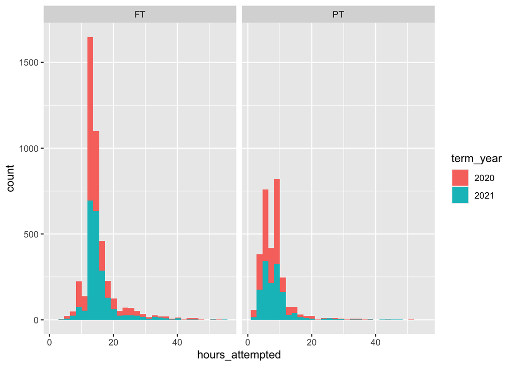

```r
p <- ggplot(df_Degrees, aes(x = hours_attempted))+ geom_histogram(aes(fill = term_year))
p1<- p + facet_wrap(~full_part)

p1
```

Boxplots of hours_attempted by year

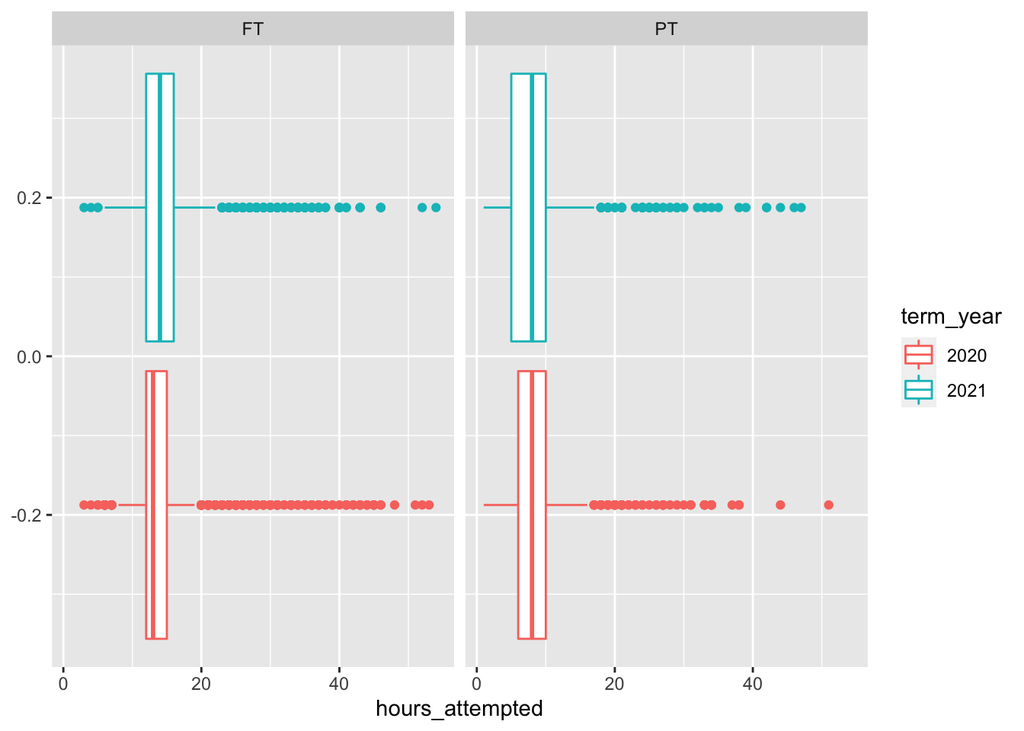

```r
p11 = ggplot(df_Degrees, aes(hours_attempted))
p11 + geom_boxplot(aes(colour = term_year)) +
       facet_wrap(~full_part)
```

Density plot of hours_attempted by year

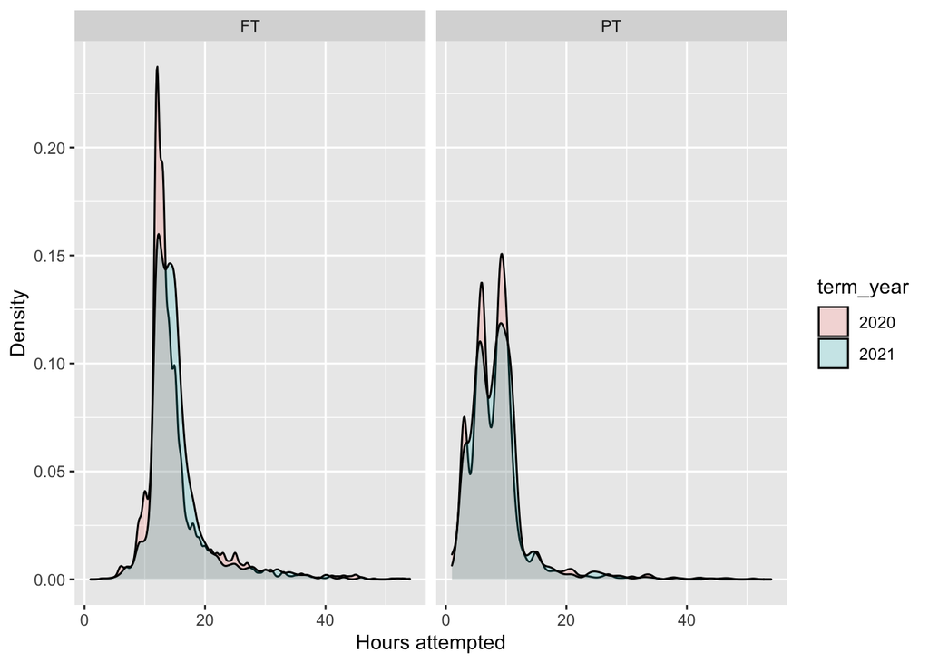

```r
ggplot(df_Degrees, aes(hours_attempted, fill = term_year)) + geom_density(alpha = 0.2) +
  facet_wrap(~full_part)+
  xlab("Hours attempted") +
  ylab( "Density")
```

Fivenum Summary

```r
df_Degrees%>% group_by(term_year,full_part)%>%
  summarise(n = n(),
            min = fivenum(hours_attempted)[1],
            Q1 = fivenum(hours_attempted)[2],
            median = fivenum(hours_attempted)[3],
            Q3 = fivenum(hours_attempted)[4],
            max = fivenum(hours_attempted)[5])
```

```
## # A tibble: 4 x 8
## # Groups:   term_year [2]
##   term_year full_part     n   min    Q1 median    Q3   max
##   <chr>     <chr>     <int> <dbl> <dbl>  <dbl> <dbl> <dbl>
## 1 2020      FT         2251     3    12     13    15    53
## 2 2020      PT         1606     1     6      8    10    51
## 3 2021      FT         2147     3    12     14    16    54
## 4 2021      PT         1373     1     5      8    10    47
```

Hours Attempted by Full-time students: The distributions for the hours attempted by full time students in term year 2020 and term year 2021 have similar shapes. The first quartile for both distributions is 12. The median for term year 2021 (14 hours attempted) is slightly higher than that in 2020 (13 hours attempted). The 3rd quartile for 2020 is 15, whilst in 2021 it is 16. Both distibutions are also skewed right and have similar tail lengths. The maxium for 2020 is 53 and in 2021 it is 54. The distribution for 2021 has lower peaks because there were less students enrolled in 2021 than in 2020. Peaks can be attributed to the fact that most courses are 3 or 4 credit courses. The college offers very few 2 credit courses.

Hours Attempted by Part-time students: The distributions for the hours attempted by part time students in term year 2020 and term year 2021 have similar shapes. The first quartile in 2021 is 5 hours and is slightly lower than 2020 ( 6hours). Both distibutions are skewed right. The right tail for 2021 is slightly shorter. The maxium for 2020 is 51 and in 2021 it is 47. The distribution for 2021 has lower peaks because there were less students enrolled in 2021 than in 2020. Peaks can be attributed to the fact that most courses are 3 or 4 credit courses. The college offers very few 2 credit courses.

Students who attempted less than 3 hours

```r
df_Degrees%>% group_by(term_year,full_part)%>%
                      count(hours_attempted<3)
```

```
## # A tibble: 6 x 4
## # Groups:   term_year, full_part [4]
##   term_year full_part `hours_attempted < 3`     n
##   <chr>     <chr>     <lgl>                 <int>
## 1 2020      FT        FALSE                  2251
## 2 2020      PT        FALSE                  1565
## 3 2020      PT        TRUE                     41
## 4 2021      FT        FALSE                  2147
## 5 2021      PT        FALSE                  1357
## 6 2021      PT        TRUE                     16
```

Students who attempted more than 18hours

```r
df_Degrees%>% group_by(term_year,full_part)%>%
                      count(hours_attempted>18)
```

```
## # A tibble: 8 x 4
## # Groups:   term_year, full_part [4]
##   term_year full_part `hours_attempted > 18`     n
##   <chr>     <chr>     <lgl>                  <int>
## 1 2020      FT        FALSE                   1925
## 2 2020      FT        TRUE                     326
## 3 2020      PT        FALSE                   1551
## 4 2020      PT        TRUE                      55
## 5 2021      FT        FALSE                   1857
## 6 2021      FT        TRUE                     290
## 7 2021      PT        FALSE                   1326
## 8 2021      PT        TRUE                      47
```

## 3.3 Hours Earned by Degree Seeking Students

Histogram of hours_earned by year

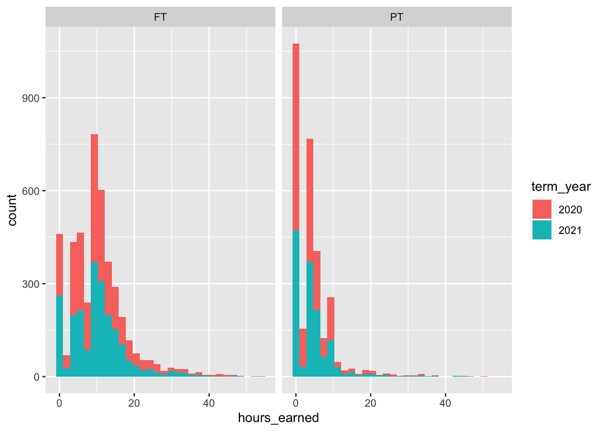

```r
p <- ggplot(df_Degrees, aes(x = hours_earned))+ geom_histogram(aes(fill = term_year))
p1<- p + facet_wrap(~full_part)

p1
```

Boxplots of hours_earned by year

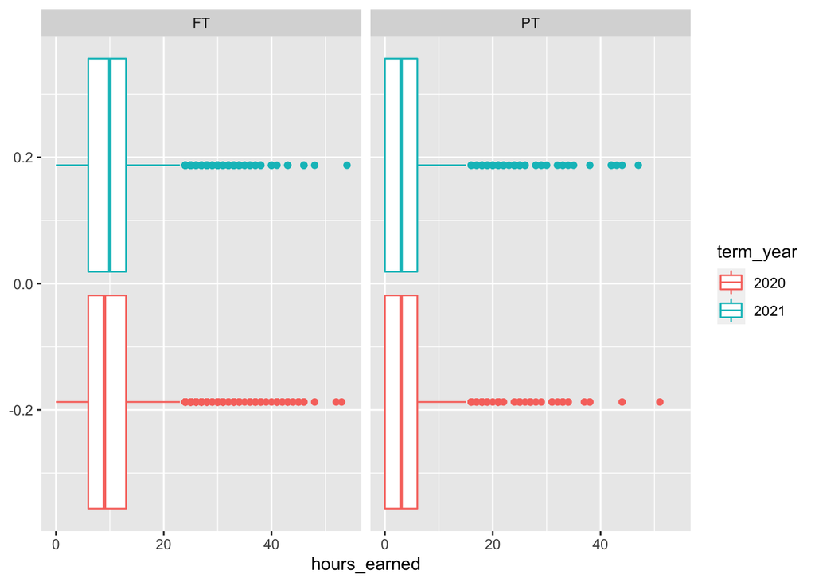

```r
p11 = ggplot(df_Degrees, aes(hours_earned))
p11 + geom_boxplot(aes(colour = term_year)) +
       facet_wrap(~full_part)
```

Density plot of hours_earned by year

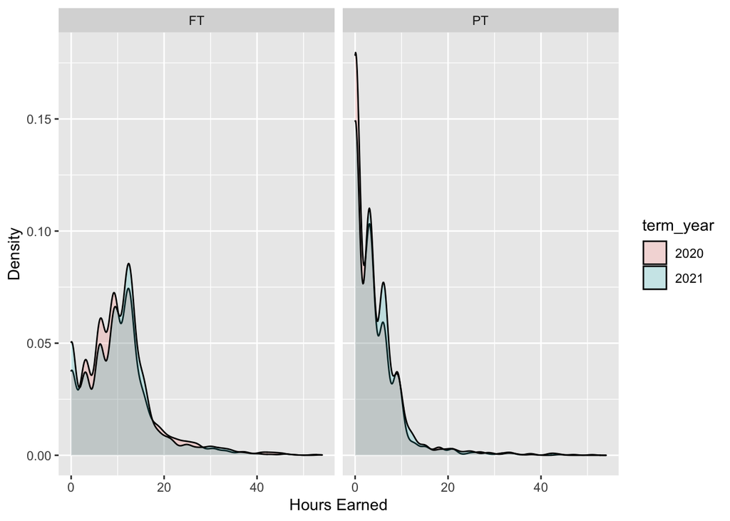

```r
ggplot(df_Degrees, aes(hours_earned, fill = term_year)) + geom_density(alpha = 0.2) +
  facet_wrap(~full_part)+
  xlab("Hours Earned") +
  ylab( "Density")
```

Hours Earned Fivenum Summary

```r
df_Degrees%>% group_by(term_year,full_part)%>%
  summarise(n = n(),
            min = fivenum(hours_earned)[1],
            Q1 = fivenum(hours_earned)[2],
            median = fivenum(hours_earned)[3],
            Q3 = fivenum(hours_earned)[4],
            max = fivenum(hours_earned)[5])
```

```
## # A tibble: 4 x 8
## # Groups:   term_year [2]
##   term_year full_part     n   min    Q1 median    Q3   max
##   <chr>     <chr>     <int> <dbl> <dbl>  <dbl> <dbl> <dbl>
## 1 2020      FT         2251     0     6      9    13    53
## 2 2020      PT         1606     0     0      3     6    51
## 3 2021      FT         2147     0     6     10    13    54
## 4 2021      PT         1373     0     0      3     6    47
```

Hours Earned Summary The distributions appeared to be skewed to the right. Incoming students are allowed to get AP credits for courses taken at highschool. The distributions for part-time student in 2020 and 2021 appear to follow a similar distribution. Peaks can be attributed to the fact that most courses are 3 or 4 credit courses. The college offers very few 2 credit courses. Students also need special permission to enroll in more than 18credits. Fulltime Students: The first quartile in term year 2020 and term year 2021 is 6 credits. The median for term year 2021 ( 10 hours earned) is slightly higher than the median in 2020 ( 9 hours earned). Both distributions has long tails on the right, with 2020 havinga maximum of 53 and 2021 having a maxium of 54. Part time Students: Both 2020 and 2021 follow a similar distribution. The first quartile for both years is 0. This means that 25% of part time students earn 0 credits. The median for both distributions is 3, ie. 50% of students earn up to 3 credits. The 3rd quartile for both distributions is 6. Both distributions have long tails.

Students who earned less than 3 hours

```r
df_Degrees%>% group_by(term_year,full_part)%>%
                      count(hours_earned<3)
```

```
## # A tibble: 8 x 4
## # Groups:   term_year, full_part [4]
##   term_year full_part `hours_earned < 3`     n
##   <chr>     <chr>     <lgl>              <int>
## 1 2020      FT        FALSE               2011
## 2 2020      FT        TRUE                 240
## 3 2020      PT        FALSE                879
## 4 2020      PT        TRUE                 727
## 5 2021      FT        FALSE               1857
## 6 2021      FT        TRUE                 290
## 7 2021      PT        FALSE                870
## 8 2021      PT        TRUE                 503
```

Students who earned more than 18 credits

```r
df_Degrees%>% group_by(term_year,full_part)%>%
                      count(hours_earned>18)
```

```
## # A tibble: 8 x 4
## # Groups:   term_year, full_part [4]
##   term_year full_part `hours_earned > 18`     n
##   <chr>     <chr>     <lgl>               <int>
## 1 2020      FT        FALSE                2015
## 2 2020      FT        TRUE                  236
## 3 2020      PT        FALSE                1568
## 4 2020      PT        TRUE                   38
## 5 2021      FT        FALSE                1955
## 6 2021      FT        TRUE                  192
## 7 2021      PT        FALSE                1333
## 8 2021      PT        TRUE                   40
```

## 3.4 Create New Variable hours_earned_rate

```r
# create variable pass_earned_hours
# hours_earned_rate = hours_earned/hours_attempted

df_Degrees<-df_Degrees %>%
           mutate(hours_earned_rate=hours_earned/hours_attempted)
```

Density plot of Hours Earned Rate by year

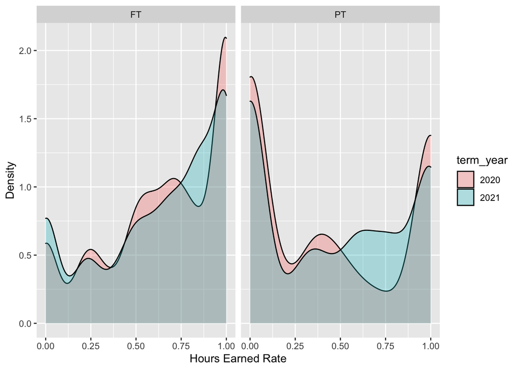

```r
ggplot(df_Degrees, aes(hours_earned_rate, fill = term_year)) + geom_density(alpha = 0.3) +
  facet_wrap(~full_part)+
  xlab("Hours Earned Rate") +
  ylab( "Density")+
  xlim(0,1)
```

## 3.5 Create New Variable unearned_hours

Unearned hours are attempted hours that the student did not receive credit for.

```r
df_Degrees<-df_Degrees %>%
           mutate(unearned_hours = hours_attempted-hours_earned)
```

Density plot of unearned hours per a year

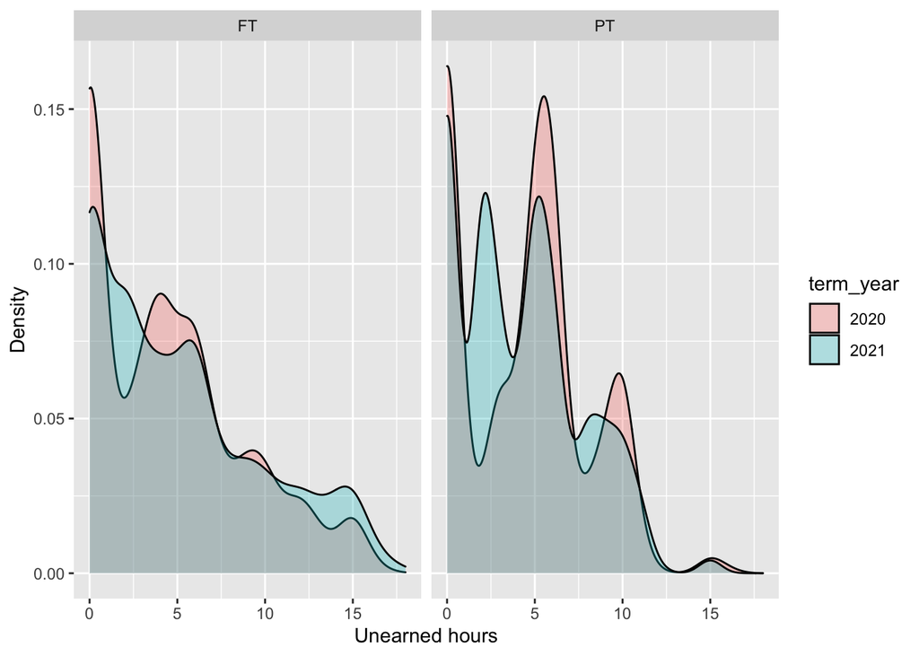

```r
ggplot(df_Degrees, aes(unearned_hours, fill = term_year)) + geom_density(alpha = 0.3) +
  facet_wrap(~full_part)+
  xlab("Unearned hours") +
  ylab( "Density") +
  xlim (0,18)
```

# 4 Exploratory Data Analysis

## 4.1 Hours Earned as a Measure of Progress

Earned credits (hours earned) are the only indication whether a student is making progress towards a degree.

Create New dataframe to clean hours earned and hours attempted.

```r
df_FTDegrees <-df_Degrees %>%
               filter(full_part=="FT")

df_FTDegrees%>% group_by(term_year)%>%
                count(term_year)
```

```
## # A tibble: 2 x 2
## # Groups:   term_year [2]
##   term_year     n
##   <chr>     <int>
## 1 2020       2251
## 2 2021       2147
```

12 credits is the minimum to qualify as a fulltime student. Check dataset for consistency. Remove if less than 12 hours attempted. Create New dataframe to clean hours earned and hours attempted.

```r
df_FTDegrees%>% group_by(term_year)%>%
                count(hours_attempted<12)
```

```
## # A tibble: 4 x 3
## # Groups:   term_year [2]
##   term_year `hours_attempted < 12`     n
##   <chr>     <lgl>                  <int>
## 1 2020      FALSE                   1975
## 2 2020      TRUE                     276
## 3 2021      FALSE                   1985
## 4 2021      TRUE                     162
```

Create a dataframe for these fulltime students who attempted less than 12 credit. Data framed called df_FT_lessC

```r
#remove certificates, NA refers to degree majors which have not been named to protect student privacy.
df_FT_lessC<-subset(df_FTDegrees, hours_attempted<12)

df_FT_lessC%>% group_by(term_year)%>%
                count(hours_attempted<12)
```

```
## # A tibble: 2 x 3
## # Groups:   term_year [2]
##   term_year `hours_attempted < 12`     n
##   <chr>     <lgl>                  <int>
## 1 2020      TRUE                     276
## 2 2021      TRUE                     162
```

There were 276 fulltime students in term year 2020 who attempted less than 12 hours. There were 162 full time students in term year 2021 who attempted less than 12 hours.

create data frame for students who earned less than 3credits or more than 18 credits. The college offers very few 2credit courses. Students need special written permission to register for more than 18credits. Students with more than 18credits could be getting AP credits.

```r
#remove certificates, NA refers to degree majors which have not been named to protect student privacy.
df_FT_outlier1<-subset(df_FTDegrees, hours_earned<3 )

df_FT_outlier1%>% group_by(term_year)%>%
                count(hours_earned<3)
```

```
## # A tibble: 2 x 3
## # Groups:   term_year [2]
##   term_year `hours_earned < 3`     n
##   <chr>     <lgl>              <int>
## 1 2020      TRUE                 240
## 2 2021      TRUE                 290
```

240 students earned less than 3 credits in 2020 and 290 students earned less than 3 credits in 2021.

I will drop these students from the dataframe.

```r
#drop students who earned less than 3 credits.
df_FTDegrees<-df_FTDegrees%>%
                subset(hours_earned>2)

df_FTDegrees%>% group_by(term_year)%>%
                count(term_year)
```

```
## # A tibble: 2 x 2
## # Groups:   term_year [2]
##   term_year     n
##   <chr>     <int>
## 1 2020       2011
## 2 2021       1857
```

Plot boxplot of distribution

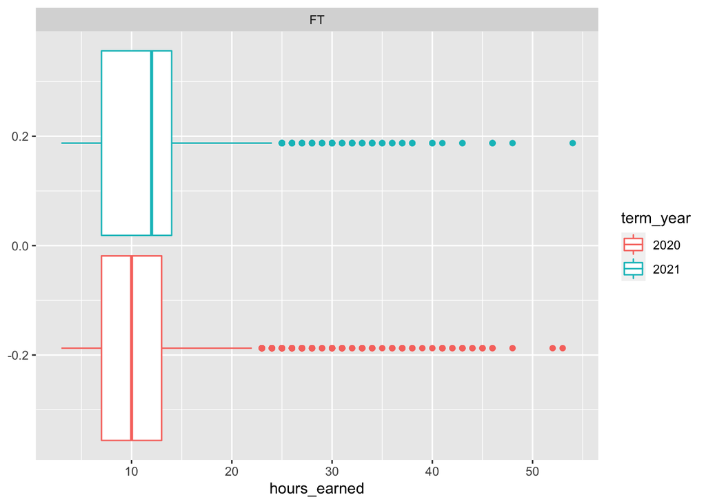

```r
p14 = ggplot(df_FTDegrees, aes(hours_earned))
p14 + geom_boxplot(aes(colour = term_year)) +
       facet_wrap(~full_part)
```

Hours Earned Fivenum Summary

```r
df_FTDegrees%>% group_by(term_year,full_part)%>%
  summarise(n = n(),
            min = fivenum(hours_earned)[1],
            Q1 = fivenum(hours_earned)[2],
            median = fivenum(hours_earned)[3],
            Q3 = fivenum(hours_earned)[4],
            max = fivenum(hours_earned)[5])
```

```
## # A tibble: 2 x 8
## # Groups:   term_year [2]
##   term_year full_part     n   min    Q1 median    Q3   max
##   <chr>     <chr>     <int> <dbl> <dbl>  <dbl> <dbl> <dbl>
## 1 2020      FT         2011     3     7     10    13    53
## 2 2021      FT         1857     3     7     12    14    54
```

drop students who earned more than 18credits.

```r
#drop students who earned more than 18 credits.
df_FTDegrees<-df_FTDegrees%>%
                subset(hours_earned<19)

df_FTDegrees%>% group_by(term_year)%>%
                count(term_year)
```

```
## # A tibble: 2 x 2
## # Groups:   term_year [2]
##   term_year     n
##   <chr>     <int>
## 1 2020       1775
## 2 2021       1665
```

Plot boxplot of distribution

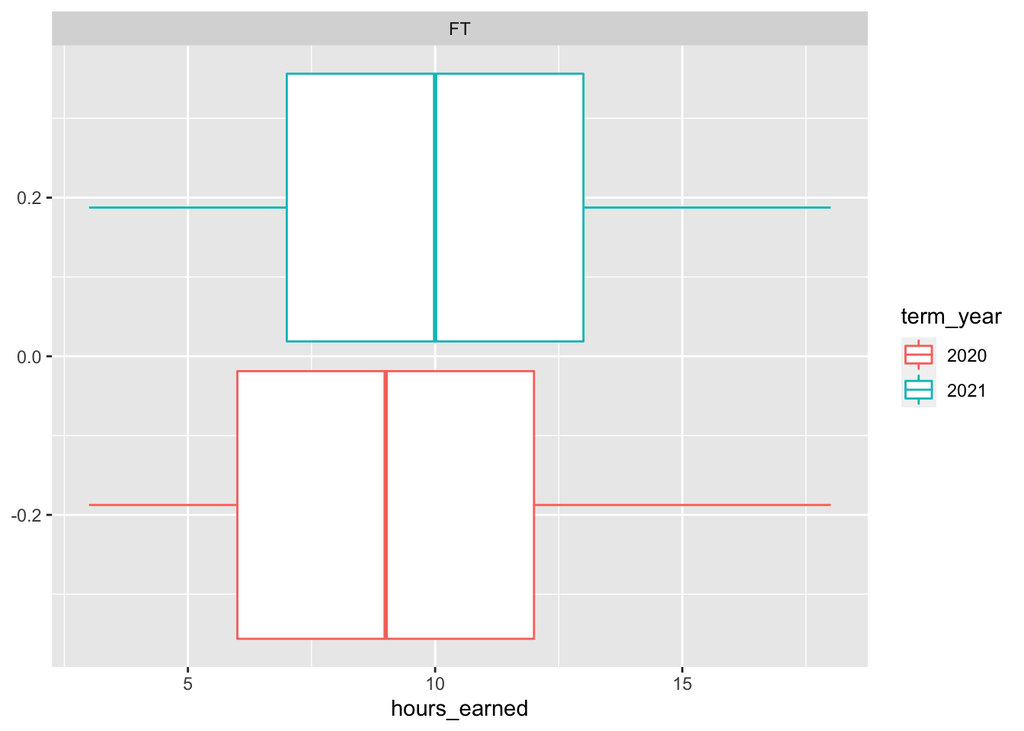

```r
p14 = ggplot(df_FTDegrees, aes(hours_earned))
p14 + geom_boxplot(aes(colour = term_year)) +
       facet_wrap(~full_part)
```

Hours Earned Fivenum Summary

```r
df_FTDegrees%>% group_by(term_year,full_part)%>%
  summarise(n = n(),
            min = fivenum(hours_earned)[1],
            Q1 = fivenum(hours_earned)[2],
            median = fivenum(hours_earned)[3],
            Q3 = fivenum(hours_earned)[4],
            max = fivenum(hours_earned)[5])
```

```
## # A tibble: 2 x 8
## # Groups:   term_year [2]
##   term_year full_part     n   min    Q1 median    Q3   max
##   <chr>     <chr>     <int> <dbl> <dbl>  <dbl> <dbl> <dbl>
## 1 2020      FT         1775     3     6      9    12    18
## 2 2021      FT         1665     3     7     10    13    18
```

Density plot of hours_earned by year

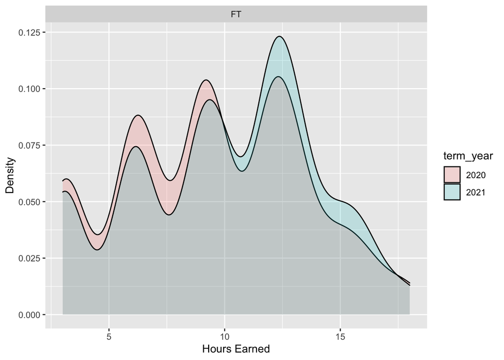

```r
ggplot(df_FTDegrees, aes(hours_earned, fill = term_year)) + geom_density(alpha = 0.2) +
  facet_wrap(~full_part)+
  xlab("Hours Earned") +
  ylab( "Density")
```

Question: Who are these students who make up this distribution.

EDA Questions: Will use degree students on

1. Difference in enrollement numbers, demographics (race, gender, highschool) in term year 2021 and term year 2020.
2. Did students in term year 2021 attempt more or less hours than students in term year 2020.
3. Did students in term year 2021 earn more or less hours than students in term year 2020.
4. Which subgroup is the best predictor of the population for hours earned. Subgroup most like the population. ( Smallest Effect Size.)